# Colchicine

Jay Brophy

September 03, 2021

# Useful functions

```r
###Plot function
#Please note that the upper_limit is manually defined to avoid ggplot to adjust it. You may have to change it.
#You may have to tweak this
my.func1 <- function(my_sd=0.28,my_mean=log(0.7047),prob_harm=TRUE,upper_limit=2.5){
  #Merely defines the subtitle of the figure
  my_text=ifelse(prob_harm,
  paste0("Probability OR>1 = ",round((1-pnorm(0,my_mean,my_sd))*100,2),"%"),
  paste0("Probability OR<1 = ",round((pnorm(0,my_mean,my_sd))*100,2),"%"))
  #Defines which area will be shaded
  my_multiplier=ifelse(prob_harm,1,-1)
  #Defines color
  my_color=ifelse(prob_harm,"blue","red")
  #Actually builds the plot
  my_plot<-ggplot(data = data.frame(x = c(-1.5, 1)), aes(x)) + #Empty plot
  geom_vline(xintercept = my_mean, color=my_color)+ #Vertical line
  geom_vline(xintercept = 0, linetype = 2)+ #Vertical Line
  stat_function(fun = dnorm, n = 1000, args = list(mean = my_mean, sd = my_sd), linetype=1)+
  geom_area(stat = "function", fun = dnorm, args = list(mean = my_mean, sd = my_sd),
  fill = "darkgray", xlim = c(0,1*my_multiplier), alpha=0.9)+
  theme_minimal()+ #You can change if you want
  labs(x="log(OR)", y="", title=paste0("Data (likelihood function) for LoDoCo2 trial"), subtitle=my_text)+
  coord_cartesian(xlim=c(-1.5,1),ylim=c(0,upper_limit))
return(my_plot)  #Returns plot
}

# function to analytically combine normal distributions
post <- function(prior.mean, prior.sd, data.mean, data.sd){
  wt.prior <- 1/ prior.sd^2
  wt.data <- 1/ data.sd^2
  post.mean <- (wt.prior  * prior.mean + wt.data * data.mean) / (wt.prior + wt.data)
  post.sd <- sqrt((wt.prior + wt.data)^-1)
  results <- list(post.mean, post.sd)
  return(results)
}


###END###
```

# Colchicine in chronic CAD

A randomized, controlled, double-blind trial comparing colchicine to placebo, in patients with chronic coronary disease (LoDoCo2) was published in the [NEJM](https://www.nejm.org/doi/full/10.1056/NEJMoa2021372#article_Abstract). The study reports a total of 5522 patients underwent randomization; 2762 were assigned to the colchicine group and 2760 to the placebo group. The median duration of follow-up was 28.6 months. A primary end-point event occurred in 187 patients (6.8%) in the colchicine group and in 264 patients (9.6%) in the placebo group (incidence, 2.5 vs. 3.6 events per 100 person-years; hazard ratio, 0.69; 95% confidence interval [CI], 0.57 to 0.83; P<0.001).

```r
library(fragility)
cat("For the statistically significant primary result in colchicine group")
```

```
## For the statistically significant primary result in colchicine group
```

```r
frag.study(e0 = 187, n0 = 2762, e1 = 264, n1 = 2760)
```

```
## ___________________________________
## Original data:
##         event no event
## group 0   187     2575
## group 1   264     2496
## Range of event modification in group 0:
##   up to 187 events modified to be non-events;
##   up to 2575 non-events modified to be events
## Range of event modification in group 1:
##   up to 264 events modified to be non-events;
##   up to 2496 non-events modified to be events
## ___________________________________
## Significance level = 0.05
## Null hypothesis: OR = 1, RR = 1, RD = 0
## p-value (two-sided):
##   0.000 based on Fisher's exact test
##   0.000 based on chi-squared test
##   0.000 based on odds ratio
##   0.000 based on relative risk
##   0.000 based on risk difference
## ___________________________________
## Fragility index (FI) and fragility quotient (FQ):
## Based on Fisher's exact test, FI = 36 (FQ = 0.7%)
##   for significance altered to non-significance,
##   achieved by inversing status of
##   36 non-events in group 0; or
##   32 non-events in group 0 and 4 events in group 1; or
##   33 non-events in group 0 and 3 events in group 1; or
##   34 non-events in group 0 and 2 events in group 1; or
##   35 non-events in group 0 and 1 event in group 1
## Based on chi-squared test, FI = 35 (FQ = 0.6%)
##   for significance altered to non-significance,
##   achieved by inversing status of
##   35 non-events in group 0; or
##   34 non-events in group 0 and 1 event in group 1
## Based on odds ratio, FI = 36 (FQ = 0.7%)
##   for significance altered to non-significance,
##   achieved by inversing status of
##   36 non-events in group 0; or
##   34 non-events in group 0 and 2 events in group 1; or
##   35 non-events in group 0 and 1 event in group 1
## Based on relative risk, FI = 36 (FQ = 0.7%)
##   for significance altered to non-significance,
##   achieved by inversing status of
##   36 non-events in group 0; or
##   34 non-events in group 0 and 2 events in group 1; or
##   35 non-events in group 0 and 1 event in group 1
## Based on risk difference, FI = 36 (FQ = 0.7%)
##   for significance altered to non-significance,
##   achieved by inversing status of
##   36 non-events in group 0; or
##   35 non-events in group 0 and 1 event in group 1
```

```r
cat("For the statistically significant result of CV death + MI in colchicine group")
```

```
## For the statistically significant result of CV death + MI in colchicine group
```

```r
frag.study(e0 = 100, n0 = 2762, e1 = 138, n1 = 2760)
```

```
## ___________________________________
## Original data:
##         event no event
## group 0   100     2662
## group 1   138     2622
## Range of event modification in group 0:
##   up to 100 events modified to be non-events;
##   up to 2662 non-events modified to be events
## Range of event modification in group 1:
##   up to 138 events modified to be non-events;
##   up to 2622 non-events modified to be events
## ___________________________________
## Significance level = 0.05
## Null hypothesis: OR = 1, RR = 1, RD = 0
## p-value (two-sided):
##   0.012 based on Fisher's exact test
##   0.014 based on chi-squared test
##   0.012 based on odds ratio
##   0.012 based on relative risk
##   0.012 based on risk difference
## ___________________________________
## Fragility index (FI) and fragility quotient (FQ):
## Based on Fisher's exact test, FI = 8 (FQ = 0.1%)
##   for significance altered to non-significance,
##   achieved by inversing status of
##   8 non-events in group 0
## Based on chi-squared test, FI = 8 (FQ = 0.1%)
##   for significance altered to non-significance,
##   achieved by inversing status of
##   8 non-events in group 0; or
##   8 events in group 1; or
##   1 non-event in group 0 and 7 events in group 1; or
##   2 non-events in group 0 and 6 events in group 1; or
##   3 non-events in group 0 and 5 events in group 1; or
##   4 non-events in group 0 and 4 events in group 1; or
##   5 non-events in group 0 and 3 events in group 1; or
##   6 non-events in group 0 and 2 events in group 1; or
##   7 non-events in group 0 and 1 event in group 1
## Based on odds ratio, FI = 8 (FQ = 0.1%)
##   for significance altered to non-significance,
##   achieved by inversing status of
##   8 non-events in group 0
## Based on relative risk, FI = 8 (FQ = 0.1%)
##   for significance altered to non-significance,
##   achieved by inversing status of
##   8 non-events in group 0
## Based on risk difference, FI = 9 (FQ = 0.2%)
##   for significance altered to non-significance,
##   achieved by inversing status of
##   9 non-events in group 0; or
##   1 non-event in group 0 and 8 events in group 1; or
##   2 non-events in group 0 and 7 events in group 1; or
##   3 non-events in group 0 and 6 events in group 1; or
##   4 non-events in group 0 and 5 events in group 1; or
##   5 non-events in group 0 and 4 events in group 1; or
##   6 non-events in group 0 and 3 events in group 1; or
##   7 non-events in group 0 and 2 events in group 1; or
##   8 non-events in group 0 and 1 event in group 1
```

```r
cat("For the statistically in significant result of no CV death  in colchicine group")
```

```
## For the statistically in significant result of no CV death  in colchicine group
```

```r
frag.study(e0 = 53, n0 = 2762, e1 = 35, n1 = 2760)
```

```
## ___________________________________
## Original data:
##         event no event
## group 0    53     2709
## group 1    35     2725
## Range of event modification in group 0:
##   up to 53 events modified to be non-events;
##   up to 2709 non-events modified to be events
## Range of event modification in group 1:
##   up to 35 events modified to be non-events;
##   up to 2725 non-events modified to be events
## ___________________________________
## Significance level = 0.05
## Null hypothesis: OR = 1, RR = 1, RD = 0
## p-value (two-sided):
##   0.067 based on Fisher's exact test
##   0.068 based on chi-squared test
##   0.055 based on odds ratio
##   0.055 based on relative risk
##   0.053 based on risk difference
## ___________________________________
## Fragility index (FI) and fragility quotient (FQ):
## Based on Fisher's exact test, FI = 2 (FQ = 0.0%)
##   for non-significance altered to significance,
##   achieved by inversing status of
##   2 non-events in group 0; or
##   2 events in group 1; or
##   1 non-event in group 0 and 1 event in group 1
## Based on chi-squared test, FI = 2 (FQ = 0.0%)
##   for non-significance altered to significance,
##   achieved by inversing status of
##   2 non-events in group 0; or
##   2 events in group 1; or
##   1 non-event in group 0 and 1 event in group 1
## Based on odds ratio, FI = 1 (FQ = 0.0%)
##   for non-significance altered to significance,
##   achieved by inversing status of
##   1 non-event in group 0; or
##   1 event in group 1
## Based on relative risk, FI = 1 (FQ = 0.0%)
##   for non-significance altered to significance,
##   achieved by inversing status of
##   1 non-event in group 0; or
##   1 event in group 1
## Based on risk difference, FI = 1 (FQ = 0.0%)
##   for non-significance altered to significance,
##   achieved by inversing status of
##   1 non-event in group 0; or
##   1 event in group 1
```

This trial recruited patients from 2 countries and was analyzed by ignoring any regional differences. However it may be of interest to analyze this data taking into account any between region variability. This seems appropriate if one wants to eventually estimate the likely result if the study was repeated in a third country.

## The data

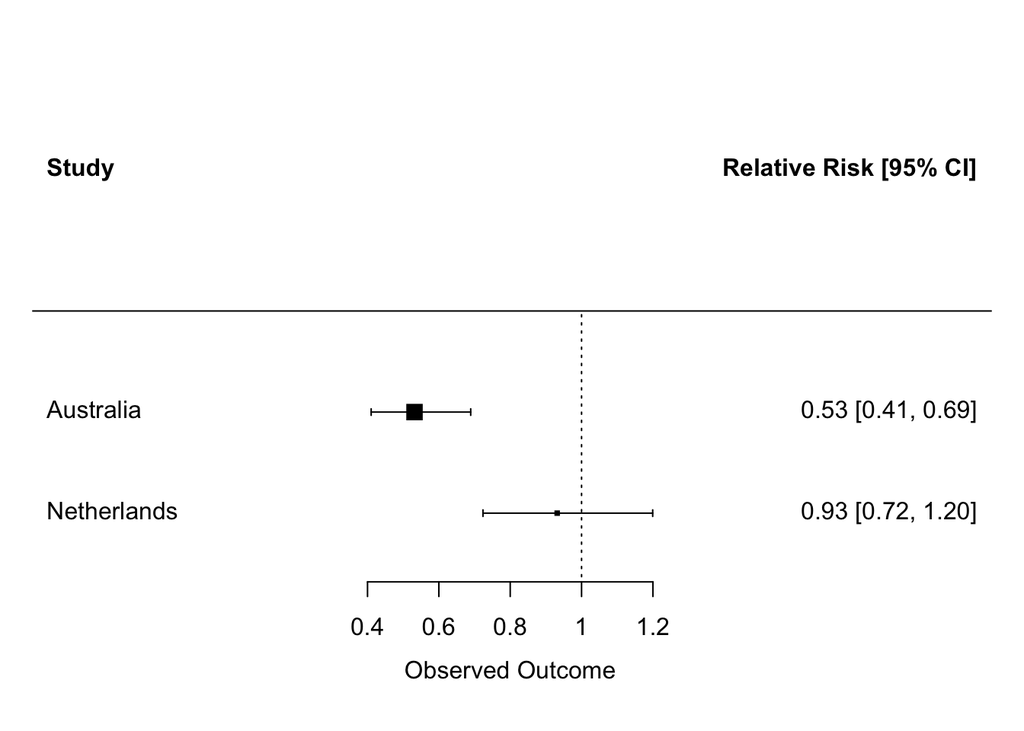

```r
country <- data.frame(study = c("Australia", "Netherlands"))
country$d0 <- c(147,117)
country$n0 <- c(953, 1807)
country$d1 <- c(78,109)
country$n1 <- c(951,1807)

## @knitr relative_risk
country$p1 <- country$d1/country$n1
country$p0 <- country$d0/country$n0
country$rr <- country$p1/country$p0
country$lrr <- log(country$rr)
country$lse <- sqrt((1 - country$p1)/(country$p1 * country$n1) + (1 - country$p0)/(country$p0 * country$n0))
country$lower <- exp(country$lrr - qnorm(.975) * country$lse)
country$upper <- exp(country$lrr + qnorm(.975) * country$lse)

## @knitr forest_plot
library("metafor")
p <- forest.default(x = country$rr, ci.lb = country$lower, ci.ub = country$upper,
       slab = paste(country$study), refline = 1)
text(min(p$xlim), .88 * max(p$ylim), "Study ", pos = 4, font = 2)
text(max(p$xlim), .88 * max(p$ylim), "Relative Risk [95% CI]", pos = 2, font = 2)
```

```r
# combining countries back to get overall LoDoCo2 results
country_comb <- country[1,2:5] + country[2,2:5]
country_comb$p1 <- country_comb$d1/country_comb$n1
country_comb$p0 <- country_comb$d0/country_comb$n0
country_comb$rr <- country_comb$p1/country_comb$p0
country_comb$lrr <- log(country_comb$rr)
country_comb$lse <- sqrt((1 - country_comb$p1)/(country_comb$p1 * country_comb$n1) + (1 - country_comb$p0)/(country_comb$p0 * country_comb$n0))
country_comb$lower <- exp(country_comb$lrr - qnorm(.975) * country_comb$lse)
country_comb$upper <- exp(country_comb$lrr + qnorm(.975) * country_comb$lse)
country_comb$study <- c("LoDoCo2")
country_comb <-  country_comb[,c(12,1:11)]
```

The relevant statistic for the meta-analysis is the relative risk ratio, $p_{1j} / p_{0j}$. We work with the log of the relative risk ratio, $y_j = log(p_{1j}) - log(p_{0j})$ with variance of each term calculated by the *delta* method as follows;

$$sigma^2_j \approx \frac{1 - p_{1j}}{n_{1j}p_{1j}} + \frac{1 - p_{0j}}{n_{0j}p_{0j}}$$

## Hierarchical model

### Frequentist approach Fig 4A

The results from the separate RCTs can be modeled using a hierarchical model. We use the fact that the log of the relative risk is approximately normally distributed and assume that the random effects follow a normal distribution,
$$y_j \sim N(\theta_j, \sigma^2_j)$$
A hierarchical model applied to meta-analysis is typically referred to as a random-effect meta-analysis model in the medical literature. The parameters of the hierarchical model can be estimated in either a frequentist or a Bayesian framework. In a frequentist setup, point estimates (rather than probability distributions) for the parameters are estimated.
$$\theta_j \sim N(\mu, \tau)$$
There are, in general, three ways to estimate the random effects, $\theta_j$
* no pooling, each study is separate $\tau = \infty$
* completing pooling all $\theta_j$ are from a common distribution, so essentially $\tau = 0$ - this is also known as fixed-effect meta-analysis model completely pools the relative risk estimates across studies. The overall mean is commonly estimated by taking an inverse-variance weighted average of studies.
* partial pooling, the hierarchical model is a compromise between the no-pooling and the complete-pooling estimates. The parameters of the hierarchical model can be estimated in either a frequentist or a Bayesian framework. In a frequentist setup, point estimates (rather than probability distributions) for the parameters are estimated.

```r
library(meta)
# no pooling - only LoDoCO trial
me.fe <- rma(country$lrr, country$lse^2, method = "FE")
cat("Completely pooled results with the point estimate followed by the 95%CI")
```

```
## Completely pooled results with the point estimate followed by the 95%CI
```

```r
c(exp(me.fe$b), exp(me.fe$ci.lb), exp(me.fe$ci.ub))
```

```
## [1] 0.7091 0.5917 0.8498
```

```r
#check to see that the point estimate is identical to taking a weighted average of the relative risks in the RCTs
#exp(weighted.mean(country$lrr, 1/(country$lse^2)))

# frequentist random effects
me.re <- rma(country$lrr, country$lse^2)
cat("Hierarchical or random effects with the point estimate ", exp(me.re$b), "followed by the 95%CI ",c(exp(me.re$ci.lb), exp(me.re$ci.ub)))
```

```
## Hierarchical or random effects with the point estimate  0.7044 followed by the 95%CI  0.4066 1.22
```

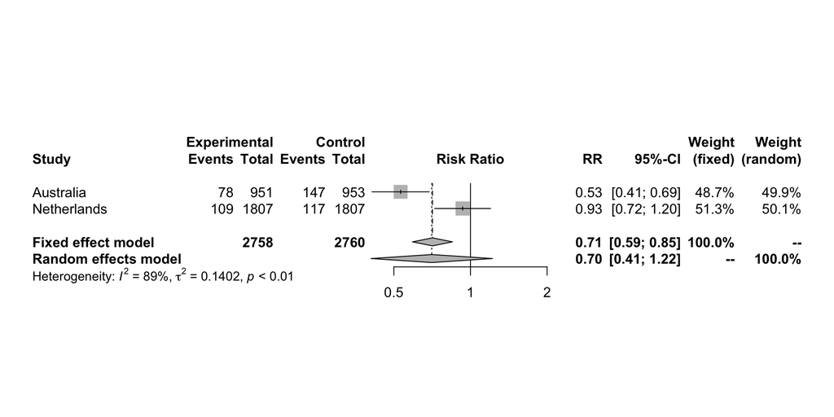

```r
m1 <- meta::metabin(country$d1, country$n1, country$d0, country$n0, sm="RR", method ="I",
                    studlab=country$study, prediction=TRUE) #, comb.random =TRUE
meta::forest(m1)
```

```r
pdf(file = 'output/col_4A.pdf', width = 12)
meta::forest(m1)
dev.off()
```

```r
png(file = 'output/col_4A.png', width = 4480,  height = 1000, res = 300)
meta::forest(m1)
dev.off()
```

```r
# backup image col_ma_fe_re_freq.png (but not sure how this was saved)

cat("Hierarchical mean =", exp(m1$TE.random), "with SD of ", m1$seTE.random, "and 95% CI ", c(exp(m1$lower.random),
exp(m1$upper.random)))
```

```
## Hierarchical mean = 0.7044 with SD of  0.2804 and 95% CI  0.4066 1.22
```

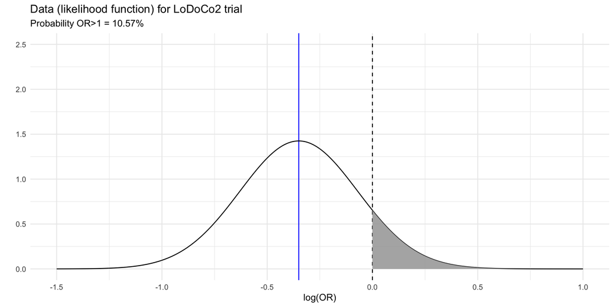

```r
my.func1(my_sd=0.28,my_mean=log(0.7047))
```

The bottom line appears that if one employs a model that captures the variability between different populations, it can be seen that while the point estimate suggests a benefit of colchicine in chronic CAD but the further studies are required to narrow our uncertainty. This is especially true since the outcome was a composite one largely driven by non-fatal outcomes  
If one wants to adopt a bayesian approach we could incorporate previous RCT (COLCT) in a similar CAD population to refine this estimate while awaiting further studies.

### Bayesian approach - vaguely informative prior Fig 4B

```r
library(MetaStan)
LoDoCo.stan  <- meta_stan(ntrt = n1,
                             nctrl = n0,
                             rtrt = d1,
                             rctrl = d0,
                             data = country,
                             tau_prior_dist = "half-normal",
                             tau_prior = 0.5,
                             theta_prior = c(0, 2.82),
                             model = "BNHM1",
                             chains = 4,
                             iter = 2000,
                             adapt_delta = .99,
                             warmup = 1000)
print(LoDoCo.stan)
```

```
## Meta-analysis using MetaStan
## Mean treatment effect
##  mean  2.5%   50% 97.5%
## -0.40 -1.25 -0.40  0.43
## Heterogeneity stdev
##  mean  2.5%   50% 97.5%
##  0.49  0.12  0.44  1.13
```

```r
print("Using MetaStan package")
```

```
## [1] "Using MetaStan package"
```

```r
cat("The Bayesian hierarchical random effects with vaguely informative prior is ", round(exp(LoDoCo.stan$fit_sum[3,1]),2), " with 95% CI ", round(exp(LoDoCo.stan$fit_sum[3,4]),2), " - ", round(exp(LoDoCo.stan$fit_sum[3,8]),2))
```

```
## The Bayesian hierarchical random effects with vaguely informative prior is  0.67  with 95% CI  0.29  -  1.54
```

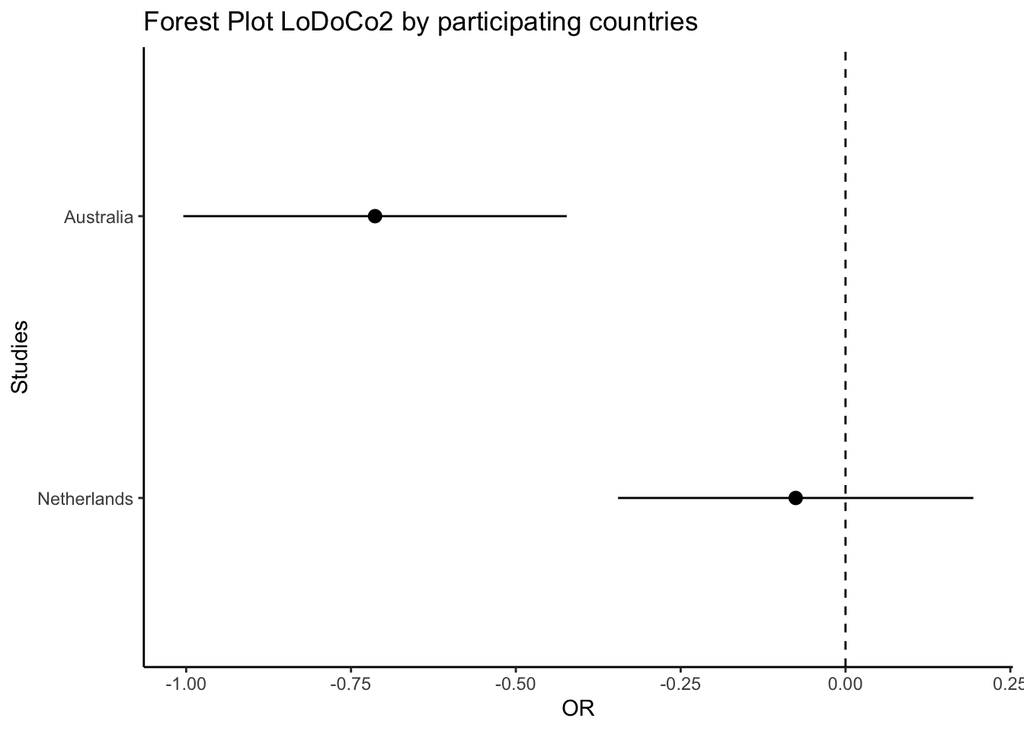

```r
#MetaStan has no plot functions so need to use the following
library(ggplot2)
# Functions to calculate log odds ratios and variances from data
logodds <- function(x) log((x[1] * (x[4] - x[3]))/((x[2] - x[1]) * x[3]))
stdes   <- function(x) sqrt(1/x[1] + 1/(x[2] - x[1]) + 1/x[3] + 1/(x[4] - x[3]))
r_ind   <- apply(cbind(country$d1, country$n1,
                       country$d0, country$n0), 1, logodds)
se_ind  <- apply(cbind(country$d1, country$n1,
                       country$d0, country$n0), 1, stdes)
lower95_ind <- r_ind + qnorm(.025) * se_ind
upper95_ind <- r_ind + qnorm(.975) * se_ind
# Comparison of the results
trials  <- c("Australia", "Netherlands")
# trials <- ordered(trials, levels = trials)

d <- data.frame(x = trials,
                y = r_ind,
                ylo = lower95_ind,
                yhi = upper95_ind)  # reverse line order if needed %>% map_df(rev)

d$x <- factor(d$x, levels=rev(d$x)) # to get right order for plot lines

forest.plot <- ggplot(d, aes(x = x, y = y, ymin = ylo, ymax = yhi)) +
  geom_pointrange() +
  coord_flip() +
  geom_hline(aes(yintercept=0), lty = 2) +
  labs(x = "Studies", y ="OR") +
  ggtitle("Forest Plot LoDoCo2 by participating countries") +
  theme_classic()

plot(forest.plot)
```

```r
# bayesmeta package
require("bayesmeta")
effsize <- escalc(measure="OR",
                  ai=d1, n1i=n1,
                  ci=d0, n2i=n0,
                  slab=study, data=country)
# perform meta-analysis:
bma <- bayesmeta(effsize, tau.prior = function(t){dhalfnormal(t, scale=0.5)})
# show results:
print(bma)
```

```
##  'bayesmeta' object.
##
## 2 estimates:
## Australia, Netherlands
##
## tau prior (proper):
## function(t){dhalfnormal(t, scale=0.5)}
## <bytecode: 0x7ff185340eb0>
##
## mu prior (improper):
## uniform(min=-Inf, max=Inf)
##
## ML and MAP estimates:
##                 tau      mu
## ML joint     0.2851 -0.3897
## ML marginal  0.4279 -0.3850
## MAP joint    0.2574 -0.3888
## MAP marginal 0.3353 -0.3850
##
## marginal posterior summary:
##               tau      mu
## mode      0.33533 -0.3850
## median    0.43524 -0.3893
## mean      0.48100 -0.3910
## sd        0.25210  0.3976
## 95% lower 0.07366 -1.2197
## 95% upper 1.00116  0.4337
##
## (quoted intervals are shortest credible intervals.)
```

```r
print("Using bayesmeta package")
```

```
## [1] "Using bayesmeta package"
```

```r
cat("The Bayesian hierarchical random effects with vaguely informative prior is ", round(exp(bma$summary[3,2]),2), " with 95% CI ",
    round(exp(bma$summary[5,2]),2),
    " - ", round(exp(bma$summary[6,2]),2))
```

```
## The Bayesian hierarchical random effects with vaguely informative prior is  0.68  with 95% CI  0.3  -  1.54
```

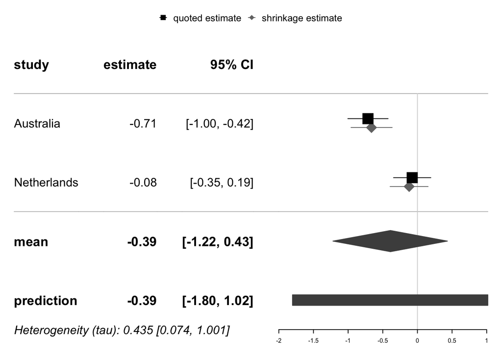

```r
# show forest plot:
forestplot(bma)
```

```r
png(file = 'output/col_4B.png', width = 4480,  height = 1000, res = 300)
forestplot(bma)
dev.off()
```

### Figure 4C

```r
#getting probabilitiies for figure

pnorm(-.1625,bma$summary[3,2], bma$summary[4,2])
```

```
## [1] 0.7172
```

```r
pnorm(0,bma$summary[3,2], bma$summary[4,2])
```

```
## [1] 0.8373
```

```r
# PDF plot
1-pnorm(0, bma$summary[3,2], bma$summary[4,2])
```

```
## [1] 0.1627
```

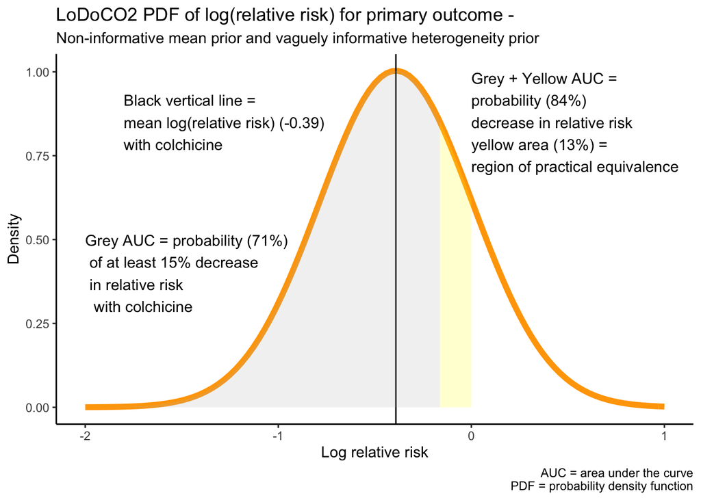

```r
lodoco_pdf <- ggplot(data.frame(x = c(-2, 1)), aes(x = x)) +
  stat_function(fun = dnorm, args = list(bma$summary[3,2], bma$summary[4,2]),  colour = "orange", size=2) +
  scale_x_continuous(name = "Log relative risk") +
  scale_y_continuous(name = "Density") +
  labs(title="LoDoCO2 PDF of log(relative risk) for primary outcome - ",
       subtitle = "Non-informative mean prior and vaguely informative heterogeneity prior", caption="AUC = area under the curve\n     PDF = probability density function") +
  geom_vline(xintercept=mean(bma$summary[3,2])) +
  annotate("text", label = "Black vertical line =\nmean log(relative risk) (-0.39)\nwith colchicine", x = -1.8, y = .85, color = "black", hjust=0) +
  annotate("text", label = "Grey AUC = probability (71%)\n of at least 15% decrease\n in relative risk\n  with colchicine", x = -2, y = .4, color = "black", hjust=0) +
  annotate("text", label = "Grey + Yellow AUC =\nprobability (84%)\ndecrease in relative risk\nyellow area (13%) =\nregion of practical equivalence", x = 0, y = .85, color = "black", hjust=0) +
  theme_classic() +
  stat_function(fun = dnorm, args = list(bma$summary[3,2], bma$summary[4,2]), xlim = c(-2,-.1625), geom = "area", fill= "gray",alpha = 0.2) +
  stat_function(fun = dnorm, args = list(bma$summary[3,2], bma$summary[4,2]), xlim = c(-.1625, 0), geom = "area", fill= "yellow",alpha = 0.2)


lodoco_pdf
```

```r
pdf("output/lodoco_pdf.pdf")
lodoco_pdf
dev.off()
```

```r
ggsave("output/col_4C.png", dpi = 300)  #lodoco_pdf.png is backup image
# uses shiny to verify model
library("shinystan")
## Firstly convert "stan" object to a "shinystan" object
LoDoCo.shinystan = as.shinystan(LoDoCo.stan$fit)
launch_shinystan(LoDoCo.shinystan)
```

## Hierarchical (random effects) - frequentist approach adding another study

A similar randomized, double-blind trial comparing colchicine to placebo but involving patients recruited within 30 days after a myocardial infarction (COLCOT) was published in the [NEJM](https://www.nejm.org/doi/10.1056/NEJMoa1912388?url_ver=Z39.88-2003&rfr_id=ori:rid:crossref.org&rfr_dat=cr_pub%20%200pubmed) and this can be included in a (frequentist) random effects meta-analysis. This study reports a total of 4745 patients were enrolled; 2366 patients were assigned to the colchicine group, and 2379 to the placebo group. Patients were followed for a median of 22.6 months. The primary end point occurred in 5.5% of the patients in the colchicine group, as compared with 7.1% of those in the placebo group (hazard ratio, 0.77; 95% confidence interval [CI], 0.61 to 0.96; P = 0.02).

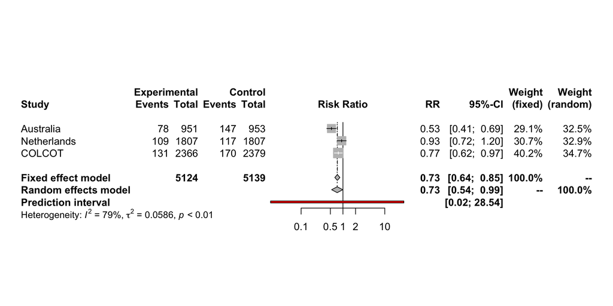

```r
# combined prior data (COLCOT) with current data from LodoCo as from hierarchical analysis
prior <- data.frame(study = c("COLCOT"))
prior$d0 <- 170
prior$n0 <- 2379
prior$d1 <- 131
prior$n1 <- 2366

## @knitr relative_risk
prior$p1 <- prior$d1/prior$n1
prior$p0 <- prior$d0/prior$n0
prior$rr <- prior$p1/prior$p0
prior$lrr <- log(prior$rr)
prior$lse <- sqrt((1 - prior$p1)/(prior$p1 * prior$n1) + (1 - prior$p0)/(prior$p0 * prior$n0))
prior$lower <- exp(prior$lrr - qnorm(.975) * prior$lse)
prior$upper <- exp(prior$lrr + qnorm(.975) * prior$lse)

comb <- rbind(country,prior)
m2 <- meta::metabin(comb$d1, comb$n1, comb$d0, comb$n0, sm="RR", method ="I",
                    studlab=comb$study, prediction=TRUE) #, comb.random =TRUE
meta::forest(m2)
```

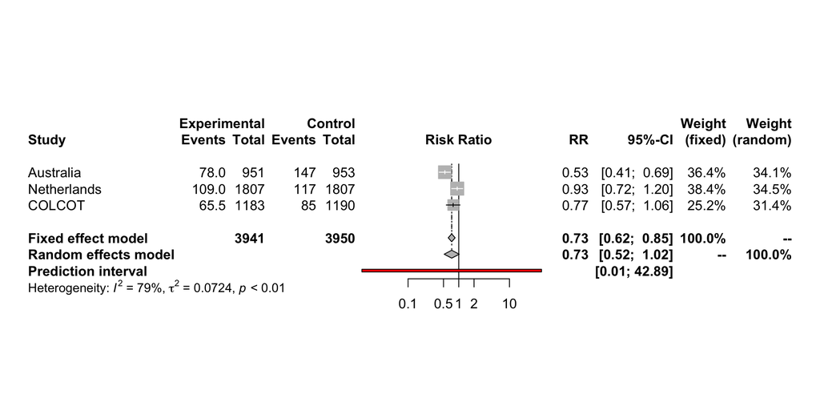

```r
# use only 1/2 COLCOT data
prior2 <- prior[,2:5]/2
prior2$study <- c("COLCOT")
prior2$p1 <- prior2$d1/prior2$n1
prior2$p0 <- prior2$d0/prior2$n0
prior2$rr <- prior2$p1/prior2$p0
prior2$lrr <- log(prior2$rr)
prior2$lse <- sqrt((1 - prior2$p1)/(prior2$p1 * prior2$n1) + (1 - prior2$p0)/(prior2$p0 * prior2$n0))
prior2$lower <- exp(prior2$lrr - qnorm(.975) * prior2$lse)
prior2$upper <- exp(prior2$lrr + qnorm(.975) * prior2$lse)

comb2 <- rbind(country,prior2)
m3 <- meta::metabin(comb2$d1, comb2$n1, comb2$d0, comb2$n0, sm="RR", method ="I",
                    studlab=comb2$study, prediction=TRUE) #, comb.random =TRUE
meta::forest(m3)
```

This first forest plot may be seen as the most optimistic as the COLCOT data is presented as a pooled results which ignores all between country (12) variations within this trial.  
Accounting for within study variation between centers in different countries, can assume that the COLCOT point estimate stays unchanged but the increased variability could be presented by considering only 1/2 the sample size, leading to the second forest plot.